# Peptide Presentation Models

Author

Alistair Bailey

Published

March 21, 2025

## Summary

Here I’ve created Bayesian regression models for the NSCLC peptidomes to model peptide presentation.

The key point is that whilst I model peptide presentation and get a probability for the likelihood of each peptide being presented, what I really care about is what is causing that probability.

There’s a lot going on here!

But the main inference is that model infers there are opposing effects on presentation from proteins presented widely across a cohort and proteins presented more strongly by a specific donor.

This implies that neoantigen candidates should be prioritised as:

1. Top Priority Candidates: peptides from proteins that show presentation in the specific donor BUT from proteins that don’t already have many other presented peptides across donors.
2. Second Tier: peptides from proteins with no presentation history with strong binding scores
3. Lower Priority: peptides from proteins that already have many presented peptides across donors

## Motivation

We don’t really know the mechanisms of how peptides get presented.

There is evidence of protein hotspots that are more likely to be presented and researchers have focused on the nature of these hotspots in terms of cellular location, ontology, protein structure and antigen presentation. Likewise the antigen processing machinery is fundamental as this is how peptides are processed and presented. The whole system is often compressed into a single metric of MHC peptide binding affinity, but sometimes includes other features such as proteosomal cleavage.

The motivation is often to identify features of interest to which machine learning can be applied.

Machine learning is of course completely valid, but it aims to identify patterns in data and make predictions, often without easy interpretation of the relative importance of the features in terms of the underlying biology.

Here I wanted to take the Bayesian approach where we quantify the contribution of features of interest to peptide presentation. This provides a better mechanistic modelling of why peptides do or don’t get presented, albeit only within our data.

To be clear, this is not a model of immunogencity, but presentation comes before immunogencity. In a natural system, a peptide that is not presented cannot be observed by the immune system and therefore cannot by definition be immunogenic.

Our estimand[^1], the parameter we wish to learn about is peptide presentation and the effects that cause it.

But if one was trying to rank peptide candidates that might be immunogenic, quantifying one’s uncertainty about whether a peptide would get presented is crucial.

## What information do we have about a lung tumour immunopeptidome?

1. We know who it came from
2. We know what cancer subtype it has be characterised as by immunohistochemistry
3. We know the HLA I and II allotypes of the donor
4. We know the length of each peptide
5. We know the amino acid sequence of each peptide
6. We know the protein from which each peptide arises

Importantly, we have this data for a **cohort of donors** which means we can use pooled information to deal with the missingness that is inherent in mass spectrometry proteomics. We next construct a Directed Acyclic Graph (DAG) of causal relationships affecting peptide presentation by HLA I and II molecules (Figure 1).

- The protein here is a latent variable that we don’t directly observe, but is identified from the peptide sequence. Hence protein is in blue (latent) and the peptide is in red (exposure).
- A proteins may yield multiple peptides, hence each peptide may compete with other peptides from the same protein for binding to HLA.
- Each donor has their own proteome, but the cohort is for a known cancer issue subtype, so we assume similarity between donor proteomes and hence both donor and cohort influence the likely existence of a protein.
- Likewise the likelihood of any HLA allotype being present is both a donor and cohort level likelihood.

What the DAG tells us is that in order to estimate the likelihood of a Peptide being presented by a HLA molecule we need to adjust for the competing effects of the Cohort, the Donor and Other peptides from that protein.

Table 1 indicates what that looks like in terms of how to represent the peptidome data.

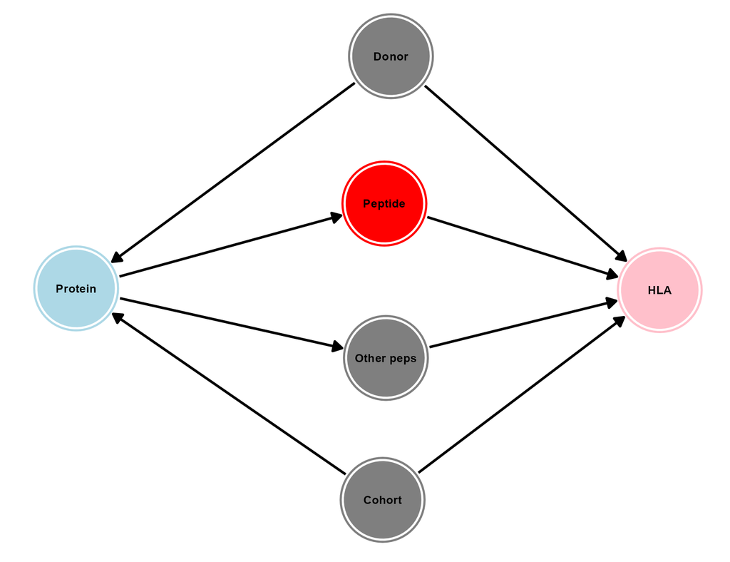

Figure 1: Directed Acyclic Graph of HLA peptide presentation across a cohort

## From the DAG to a model

Using the information contained in the observed LUAD and LUSC peptidomes and predicted binding affinity for each peptide to either HLA-I or HLA-II for a cohort of donors I built a model to infer:

1. **The Probability of Peptide Presentation**
   - For each peptide, the model estimates the probability it will be presented
2. **HLA-Specific Effects**
   - How peptide length preferences differ across HLA allotypes
   - How binding score relates to presentation probability
3. **Proteome Effects**
   - How the presence of other peptides from the same protein in the same donor affects presentation
   - How the presence of other peptides from the same protein in the overall cohort affects presentation (this might seem slightly odd, but we’re essentially borrowing information from other donors to understand the propensity of each protein to be presented in general)
4. **Random Effect Variance Components**
   - Donor-specific variation in overall presentation rates
   - Protein-specific variation in presentation likelihood
   - Donor-proteome variation effects

### Data format

For each NSCLC cohort and HLA class, the data is collated into a table. For example for LUAD HLA-I there are 42,303 unique peptide sequences.

Table 1 shows a sample of 10 peptides where for each row 1 or 0 indicates whether the peptide was observed for that donor. The other columns contain information relating to the peptide and the donor such as `has_hla` means “Does the donor have the HLA allotype this pepitde is predicted to bind to?” and `n_observed_cohort` indicates “How many HLA-I peptides were seen from this protein across the cohort?”. This is how the DAG (Figure 1) is represented in terms of the data so we can examine the identified effects on peptide presentation.

Table 1: Example of LUAD HLA-I data for model

| peptide_presentation | donor | peptide_sequence_id | peptide_sequence | peptide_length | hla | peptide_binding_score | uniprot_id | has_hla | n_peptides | n_observed_donor | n_observed_cohort | length_diff_from_9 |
| --- | --- | --- | --- | --- | --- | --- | --- | --- | --- | --- | --- | --- |
| 1 | A114 | 5759 | ALVVQVAEA | 9 | A0201 | -0.4 | P07686 | TRUE | 20 | 6 | 20 | 0 |
| 0 | A146 | 13143 | VFQERINCL | 9 | B0801 | 0.037 | Q9BZV1 | TRUE | 6 | 0 | 6 | 0 |
| 0 | A136 | 9085 | SLDSVEALL | 9 | A0201 | -0.006 | Q13813 | TRUE | 202 | 6 | 197 | 0 |
| 1 | A117 | 23021 | KEVTAIETKL | 10 | B4001 | 0.501 | Q14683 | TRUE | 18 | 3 | 18 | 1 |
| 0 | A139 | 27092 | AEGDIGKTGTIAL | 13 | B4001 | 0.46 | Q68DQ2 | TRUE | 25 | 4 | 25 | 4 |
| 1 | A119 | 16215 | RVNIPKVLR | 9 | A3101 | 1.2 | Q00610 | TRUE | 229 | 25 | 217 | 0 |
| 0 | A137 | 15643 | IRTGLVRLL | 9 | B2705 | 0.024 | P53992 | TRUE | 34 | 3 | 33 | 0 |
| 0 | A137 | 21467 | ILNNKLISK | 9 | A0301 | 0.791 | Q9ULX6 | TRUE | 6 | 0 | 5 | 0 |
| 0 | A143 | 6330 | HLGVVTGV | 8 | A0201 | -0.162 | O75023 | TRUE | 4 | 0 | 4 | -1 |
| 0 | A136 | 40880 | LPFLKSLEF | 9 | B3501 | -0.005 | P31323 | TRUE | 3 | 0 | 3 | 0 |

### Bayesian regression model

The peptidome data as illustrated in Table 1 represents our knowledge about peptide presentation and what Bayesian regression does is count the ways in which this data could have arisen given (my) prior assumptions of the causes of the data illustrated in the DAG Figure 1. These counts create a probability distribution such that things that happen more often are more plausible.

Each model fits the parameters identified and produces a posterior probability from which we can examine the contributions of each parameter on overall peptide presentation outcome. In this way, the posterior probability informs us: we either saw the peptide or we didn’t and the posterior hopefully tells us more about **why.**

Each multilevel model can be represented mathematically as follows:

$$\begin{align}
y_i &\sim \text{Bernoulli}(\pi_i) \\
\text{logit}(\pi_i) &= \eta_i
\end{align}$$

where $y_i$ is the binary outcome variable representing peptide presentation, and $\eta_i$ is the linear predictor:

$$\begin{align}
\eta_i &= \beta_0 + \sum_{j=1}^{J} \beta_j H_{ij} \\
&+ \beta_{B} \cdot B_i + \sum_{j=1}^{J} \beta_{B \times j} \cdot B_i \cdot H_{ij} \\
&+ \beta_{L} \cdot L_i + \sum_{j=1}^{J} \beta_{L \times j} \cdot L_i \cdot H_{ij} \\
&+ \beta_{PD} \cdot PD_i + \beta_{PC} \cdot PC_i \\
&+ u_{\text{donor}[i]} + u_{\text{donor:protein}[i]} + u_{\text{protein}[i]}
\end{align}$$

Where:

- $\pi_i$ is the probability of peptide presentation for observation $i$
- $\beta_0$ is the global intercept - $\beta_j$ is the fixed effect for HLA type $j$
- $B_i$ represents `binding_score` for observation $i$
- $L_i$ represents `length_diff` for observation $i$ (difference from reference length)
- $PD_i$ represents `protein_has_other_peptides_donor` for observation $i$
- $PC_i$ represents `protein_has_other_peptides_cohort` for observation $i$
- $H_{ij}$ is an indicator variable for whether observation $i$ has HLA type $j$
- $\beta_{B \times j}$ are the HLA-specific binding score effects
- $\beta_{L \times j}$ are the HLA-specific length difference effects

The random effects are distributed as:

$$\begin{align}
u_{\text{donor}} &\sim \mathcal{N}(\mathbf{0}, \sigma^2_{\text{donor}}\mathbf{I}) \\
u_{\text{donor:protein}} &\sim \mathcal{N}(\mathbf{0}, \sigma^2_{\text{donor:protein}}\mathbf{I}) \\
u_{\text{protein}} &\sim \mathcal{N}(\mathbf{0}, \sigma^2_{\text{protein}}\mathbf{I})
\end{align}$$

where:

- $\sim \mathcal{N}(\mathbf{0}, \sigma^2\mathbf{I})$ indicates a multivariate normal distribution with a mean of zero and variance $\sigma^2$.
- $\mathbf{I}$ is the identity matrix, indicating that the random effects are independent of each other

The random effects allow for some random variation in donor peptide processing, donor proteomes and protein presentation propensity, such that:

- Donors with few observations get shrunk more toward the population mean (more pooling of cohort level information)
- Donors with many observations retain more of their raw estimates (less pooling of cohort level information)
- The amount of shrinkage is determined by the ratio of between-donor variance to within-donor variance

This aims to:

- Account for true heterogeneity: Different donors are likely to have different baseline propensities for peptide presentation
- Account for sparse data: Some donor/protein combinations might have few observations
- Identify protein-specific effects: Capture inherent differences in presentability between proteins
- Improve prediction: Particularly for rare donor-peptide combinations
- Quantify the variability through each random effect variance parameter $\sigma^2$

## Results

- Prior predictive checks: these confirm the model is sensible. Not included here.
- Posterior predictive checks: what the model is telling us about parameter effects on peptide presentation.

### Average effects

These aspects are of most interest to us when thinking about whether a peptide we want to be presented is likely to be presented i.e. a putative neoantigen. Average effects are those that assume “all else is equal” such that other parameters are held constant whilst those of interest vary.

#### Average predicted peptide length effect

1. What is the effect of the peptide length on each HLA allotype on peptide presentation?

What Figure 2 and Figure 3 show is how some HLA allotypes are on average sensitive to peptide length for presentation, but most are fairly insensitive.

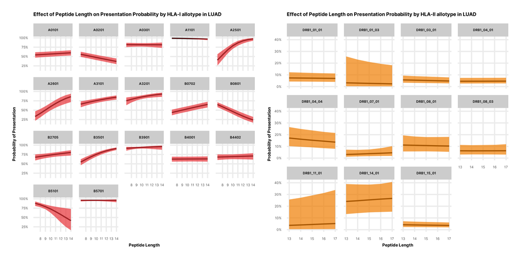

Figure 2: LUAD HLA peptide length effects on peptide presentation

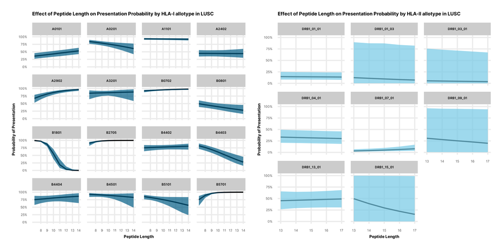

Figure 3: LUSC HLA peptide length effects on peptide presentation

#### Average comparisons

Comparisons compare the average effects on peptide presentation, such as

- The effect of observing peptides other peptides from that protein for that donor compared to the effect of observing peptides other peptides from that protein across the cohort.

What Table 2, Figure 4 and Figure 5 show is the opposing effects of a protein presenting peptides widely across the cohort or more specifically to a donor on the likelihood of a peptide being presented.

For example, the top line of the Table 2 indicates that a peptide from a given protein is on average 56% less likely to be presented if other peptides from that protein has been observed multiple times across the LUAD HLA-I peptidomes.

Whereas if a donor has presented other peptides from a protein it is on average 13% more likely to present another peptide for a LUAD HLA-I donor peptidome.

And so on. The plots show how tight the distributions of uncertainty are.

This is why we would prioritise neoantigen candidates from proteins that show presentation in the specific donor BUT from proteins that don’t already have many other presented peptides across donors. Along with choosing the optimal length for the HLA allotype and a strong binding prediction.

Table 2: Average effect of source protein on peptide presentation

| Peptidome | Source protein | % Change | 2.5% | 97.5% |
| --- | --- | --- | --- | --- |
| LUAD HLA-I | Other peptides in cohort | -0.56 | -0.56 | -0.55 |
| LUAD HLA-I | Other peptides in donor | 0.13 | 0.13 | 0.14 |
| LUAD HLA-II | Other peptides in cohort | -0.64 | -0.64 | -0.63 |
| LUAD HLA-II | Other peptides in donor | 0.27 | 0.26 | 0.28 |
| LUSC HLA-I | Other peptides in cohort | -0.31 | -0.33 | -0.29 |
| LUSC HLA-I | Other peptides in donor | 0.13 | 0.12 | 0.14 |
| LUSC HLA-II | Other peptides in cohort | -0.42 | -0.46 | -0.38 |
| LUSC HLA-II | Other peptides in donor | 0.28 | 0.26 | 0.29 |

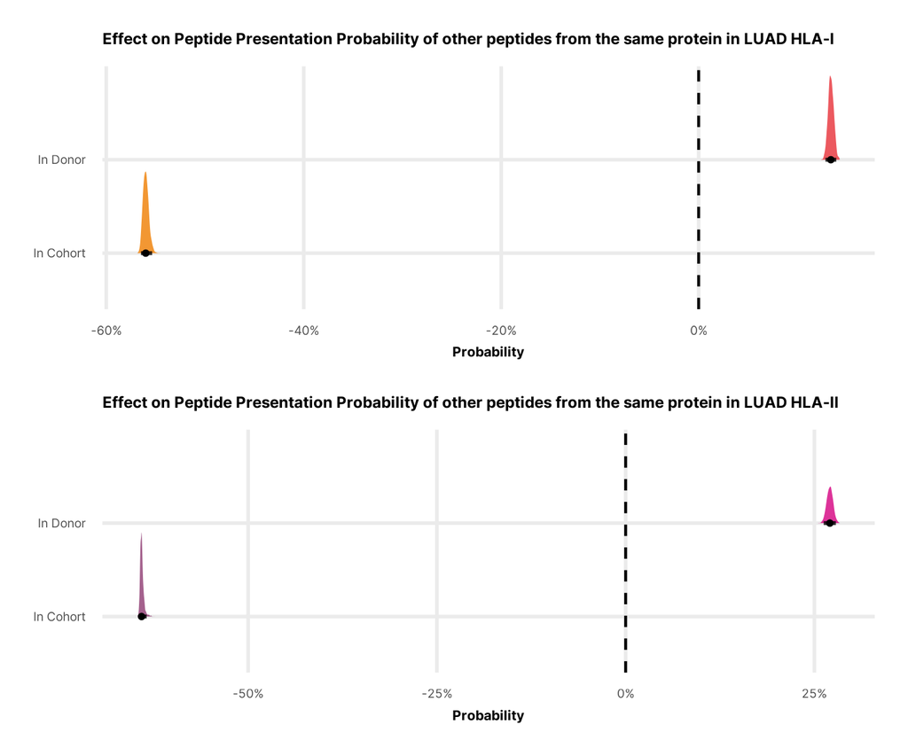

Figure 4: LUAD source protein effects

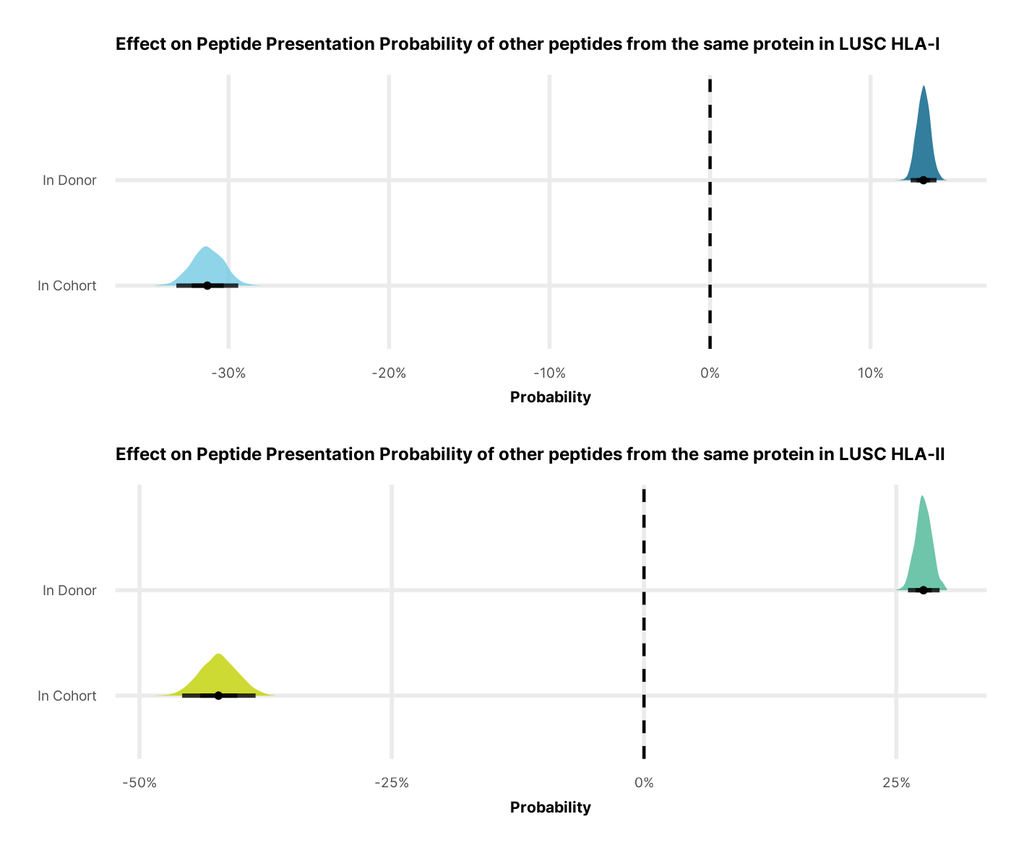

Figure 5: LUSC source protein effects

### Predictions

I’ve taken the original pVACseq predictions that we tested using ELISpot (Figure 6) and used the model to predict how likely each peptide is to be presented. Remember this is not predicting immunogenicity, but it shows how we might have chosen different candidates had we used this information.

I’ve plotted this in terms of ranking such that the pVACseq ranking is compared to the presentation ranking likelihood.

For example, for A119 HLA-II peptide 01-CANT1 was highly ranked with both predictions, and gave a very strong response. Whereas HLA-I peptide 12-PTPRT was highly ranked by pVACseq, but had a predicted low likelihood of presentation, and is also a very strong response (Figure 7).

Obviously in an ideal world, we’d investigate, but it suggests that CANT1 may be a true neoantigen and PTPRT works in ELISpot, but may not have clinical efficacy. Or something else!

I’ve plotted the top 10 re-ranked peptides using the presentation model compared to pVACseq for A119 to further show the differences (Figure 8).

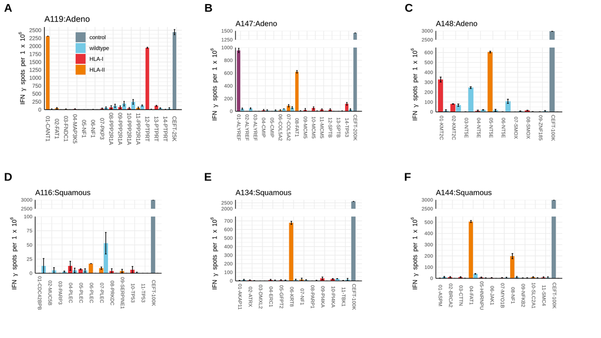

Figure 6: The actual ELISpot data

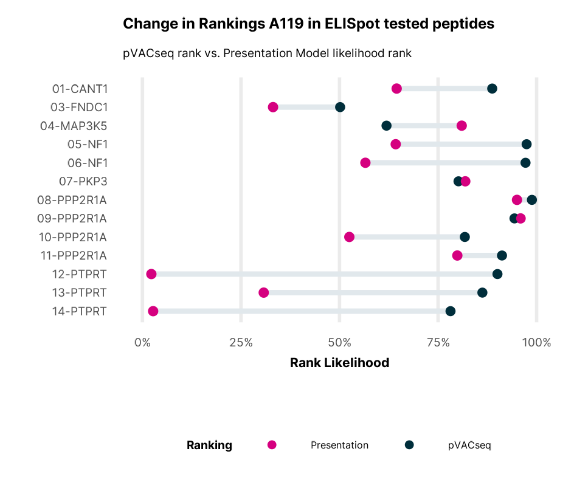

Figure 7: Note: pVACseq attempts to predict reactive neoantigens, but peptide presentation model only predicts presentation.

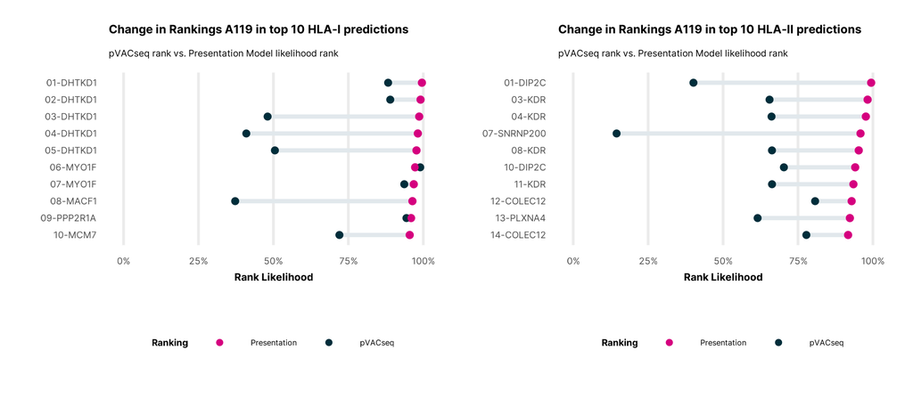

Figure 8

## Footnotes

[^1]: This unfortunate reality of the difference between the estimand, the estimator and the estimate.

[figure not shown]